# Exploration of 2016 Presidential Campaign by Steven Lin

```
## [1] "C:/Users/stlin/Dropbox/R Project/Submittion"
```

```
## 'data.frame':    1304346 obs. of  18 variables:
##  $ cmte_id          : chr  "C00575795" "C00575795" "C00575795" "C00580100" ...
##  $ cand_id          : Factor w/ 25 levels "P00003392","P20002671",..: 1 1 1 23 12 23 12 12 12 1 ...
##  $ cand_nm          : Factor w/ 25 levels "Bush, Jeb","Carson, Benjamin S.",..: 4 4 4 23 20 23 20 20 20 4 ...
##  $ contbr_nm        : Factor w/ 231294 levels "'CALL, BARBARA",..: 7753 31629 70312 175051 117924 176417 119377 119377 119411 92354 ...
##  $ contbr_city      : Factor w/ 2534 levels "","-4086","#NAME?",..: 1136 324 729 1183 323 1913 1810 1810 2402 1094 ...
##  $ contbr_st        : Factor w/ 1 level "CA": 1 1 1 1 1 1 1 1 1 1 ...
##  $ contbr_zip       : Factor w/ 143656 levels "","00000","000090272",..: 115155 71795 53864 126927 66455 139488 17327 17327 45924 58804 ...
##  $ contbr_employer  : Factor w/ 65600 levels "","''RETIRED''",..: 38794 38794 38794 27608 4491 27608 62116 62116 41406 38794 ...
##  $ contbr_occupation: Factor w/ 28622 levels "","''RETIRED''",..: 21476 21476 21476 12737 23942 12737 17980 17980 19679 21476 ...
##  $ contb_receipt_amt: num  50 200 5 48.3 40 ...
##  $ contb_receipt_dt : Factor w/ 732 levels "01-APR-15","01-APR-16",..: 596 446 27 486 85 564 108 132 85 446 ...
##  $ receipt_desc     : Factor w/ 74 levels "","* EARMARKED CONTRIBUTION: SEE BELOW REATTRIBUTION/REFUND PENDING",..: 1 1 1 1 1 1 1 1 1 1 ...
##  $ memo_cd          : Factor w/ 2 levels "","X": 2 2 2 2 1 2 1 1 1 2 ...
##  $ memo_text        : Factor w/ 428 levels "","$0.02 REFUNDED ON 10/21/2016",..: 126 126 126 1 90 1 90 90 90 126 ...
##  $ form_tp          : Factor w/ 3 levels "SA17A","SA18",..: 2 2 2 2 1 2 1 1 1 2 ...
##  $ file_num         : int  1091718 1091718 1091718 1146165 1077404 1146165 1077404 1077404 1077404 1091718 ...
##  $ tran_id          : Factor w/ 1300659 levels "A000771210424405B8CF",..: 466737 466019 463401 852428 1037145 890506 1038589 1040890 1036607 466057 ...
##  $ election_tp      : Factor w/ 5 levels "","G2016","O2016",..: 4 4 4 2 4 2 4 4 4 4 ...
```

This campaign dataset looks doesn’t have much information about the candidates. I think it could be interesting to add candidates’s gender, political party and age into my exploratory analysis. Google search presidential candidate 2016 to find link that gives relevant info: http://presidential-candidates.insidegov.com/ I add in these info into an R dataframe and join to the camp dataframe.

I also want to add a column representing the “County”. This column will be created by joining the camp dataset with the table I obtain online with zip code to county mapping. Link: http://www.zipcodestogo.com/California/ This “county” column is going to be used to create the map plot later on.

# Univariate Plots Section

```
## 'data.frame':    1304346 obs. of  25 variables:
##  $ cmte_id          : chr  "C00575795" "C00575795" "C00575795" "C00580100" ...
##  $ cand_id          : Factor w/ 25 levels "P00003392","P20002671",..: 1 1 1 23 12 23 12 12 12 1 ...
##  $ cand_nm          : Factor w/ 25 levels "Bush, Jeb","Carson, Benjamin S.",..: 4 4 4 23 20 23 20 20 20 4 ...
##  $ contbr_nm        : Factor w/ 231294 levels "'CALL, BARBARA",..: 7753 31629 70312 175051 117924 176417 119377 119377 119411 92354 ...
##  $ contbr_city      : Factor w/ 2534 levels "","-4086","#NAME?",..: 1136 324 729 1183 323 1913 1810 1810 2402 1094 ...
##  $ contbr_st        : Factor w/ 1 level "CA": 1 1 1 1 1 1 1 1 1 1 ...
##  $ contbr_zip       : Factor w/ 143656 levels "","00000","000090272",..: 115155 71795 53864 126927 66455 139488 17327 17327 45924 58804 ...
##  $ contbr_employer  : Factor w/ 65600 levels "","''RETIRED''",..: 38794 38794 38794 27608 4491 27608 62116 62116 41406 38794 ...
##  $ contbr_occupation: Factor w/ 28622 levels "","''RETIRED''",..: 21476 21476 21476 12737 23942 12737 17980 17980 19679 21476 ...
##  $ contb_receipt_amt: num  50 200 5 48.3 40 ...
##  $ contb_receipt_dt : Factor w/ 732 levels "01-APR-15","01-APR-16",..: 596 446 27 486 85 564 108 132 85 446 ...
##  $ receipt_desc     : Factor w/ 74 levels "","* EARMARKED CONTRIBUTION: SEE BELOW REATTRIBUTION/REFUND PENDING",..: 1 1 1 1 1 1 1 1 1 1 ...
##  $ memo_cd          : Factor w/ 2 levels "","X": 2 2 2 2 1 2 1 1 1 2 ...
##  $ memo_text        : Factor w/ 428 levels "","$0.02 REFUNDED ON 10/21/2016",..: 126 126 126 1 90 1 90 90 90 126 ...
##  $ form_tp          : Factor w/ 3 levels "SA17A","SA18",..: 2 2 2 2 1 2 1 1 1 2 ...
##  $ file_num         : int  1091718 1091718 1091718 1146165 1077404 1146165 1077404 1077404 1077404 1091718 ...
##  $ tran_id          : Factor w/ 1300659 levels "A000771210424405B8CF",..: 466737 466019 463401 852428 1037145 890506 1038589 1040890 1036607 466057 ...
##  $ election_tp      : Factor w/ 5 levels "","G2016","O2016",..: 4 4 4 2 4 2 4 4 4 4 ...
##  $ cand_party       : Factor w/ 5 levels "Democratic Party",..: 1 1 1 5 1 5 1 1 1 1 ...
##  $ cand_residence   : Factor w/ 24 levels "Austin, TX","Baltimore, MD",..: 7 7 7 16 5 16 5 5 5 7 ...
##  $ cand_gender      : Factor w/ 2 levels "Female","Male": 1 1 1 2 2 2 2 2 2 1 ...
##  $ cand_age         : num  70 70 70 71 76 71 76 76 76 70 ...
##  $ zip_code_clean   : chr  "94939" "93428" "92337" "95334" ...
##  $ City             : Factor w/ 1238 levels "Acampo","Acton",..: 578 156 376 602 155 942 902 902 1167 562 ...
##  $ County           : Factor w/ 58 levels "Alameda","Alpine",..: 21 40 36 24 56 34 19 19 37 30 ...
```

```
##    cmte_id               cand_id                            cand_nm
##  Length:1304346     P00003392:688524   Clinton, Hillary Rodham  :688524
##  Class :character   P60007168:407164   Sanders, Bernard         :407164
##  Mode  :character   P80001571: 86258   Trump, Donald J.         : 86258
##                     P60006111: 57822   Cruz, Rafael Edward 'Ted': 57822
##                     P60005915: 27370   Carson, Benjamin S.      : 27370
##                     P60006723: 14095   Rubio, Marco             : 14095
##                     (Other)  : 23113   (Other)                  : 23113
##             contbr_nm              contbr_city     contbr_st
##  PETIT, MICHAEL  :    473   LOS ANGELES  :102710   CA:1304346
##  MITCHELL, MARCIA:    409   SAN FRANCISCO: 90937
##  SMITH, CHERYL   :    375   SAN DIEGO    : 46129
##  SAMATUA, DENISE :    373   OAKLAND      : 33235
##  CARROLL, TERI   :    352   SAN JOSE     : 30674
##  ADAM, MONIQUE   :    321   SACRAMENTO   : 23799
##  (Other)         :1302043   (Other)      :976862
##      contbr_zip           contbr_employer               contbr_occupation
##  92660    :    660   N/A          :185382   RETIRED              :260546
##  92037    :    565   RETIRED      :121569   NOT EMPLOYED         :115598
##  90049    :    495   SELF-EMPLOYED:120187   ATTORNEY             : 36640
##  92677    :    483   NONE         : 84297   INFORMATION REQUESTED: 30948
##  92067    :    474   NOT EMPLOYED : 50821   TEACHER              : 29104
##  911075001:    473   (Other)      :741411   (Other)              :831369
##  (Other)  :1301196   NA's         :   679   NA's                 :   141
##  contb_receipt_amt   contb_receipt_dt
##  Min.   :-10500.0   29-FEB-16:  11735
##  1st Qu.:    15.0   31-MAR-16:  11506
##  Median :    27.0   31-MAY-16:  10435
##  Mean   :   116.2   31-OCT-16:  10220
##  3rd Qu.:    88.0   06-NOV-16:  10199
##  Max.   : 10800.0   01-NOV-16:  10082
##                     (Other)  :1240169
##                                   receipt_desc     memo_cd
##                                         :1287456    :1104791
##  Refund                                 :  10413   X: 199555
##  REDESIGNATION FROM PRIMARY             :   1324
##  REDESIGNATION TO GENERAL               :   1324
##  REATTRIBUTION / REDESIGNATION REQUESTED:    569
##  REDESIGNATION TO CRUZ FOR SENATE       :    544
##  (Other)                                :   2716
```

[output cut: 25 more lines]

```
##  Min.   :41.00   Length:1304346     Los Angeles  :106344
##  1st Qu.:70.00   Class :character   San Francisco: 90980
##  Median :70.00   Mode  :character   San Diego    : 46072
##  Mean   :70.43                      Oakland      : 34434
##  3rd Qu.:76.00                      San Jose     : 30668
##  Max.   :76.00                      (Other)      :993358
##                                     NA's         :  2490
##            County
##  Los Angeles  :339963
##  San Diego    :101473
##  Alameda      : 96611
##  San Francisco: 90949
##  Orange       : 85709
##  (Other)      :587151
##  NA's         :  2490
```

```
##                      cand_name              cand_party
##  Bush, Jeb                : 1   Democratic Party : 5
##  Carson, Benjamin S.      : 1   Green Party      : 1
##  Christie, Christopher J. : 1   Independent      : 1
##  Clinton, Hillary Rodham  : 1   Libertarian Party: 1
##  Cruz, Rafael Edward 'Ted': 1   Republican Party :17
##  Fiorina, Carly           : 1
##  (Other)                  :19
##            cand_residence cand_gender    cand_age
##  Baltimore, MD    : 2     Female: 3   Min.   :41.00
##  Austin, TX       : 1     Male  :22   1st Qu.:55.00
##  Baton Rouge, LA  : 1                 Median :63.00
##  Bowling Green, KY: 1                 Mean   :60.76
##  Burlington, VT   : 1                 3rd Qu.:67.00
##  Cambridge, MA    : 1                 Max.   :76.00
##  (Other)          :18
```

I am curious on the age distribution of the candidates, so create histogram below to see. Age is between 41 to 76, whilte more candidates is between 60 to 70 range.

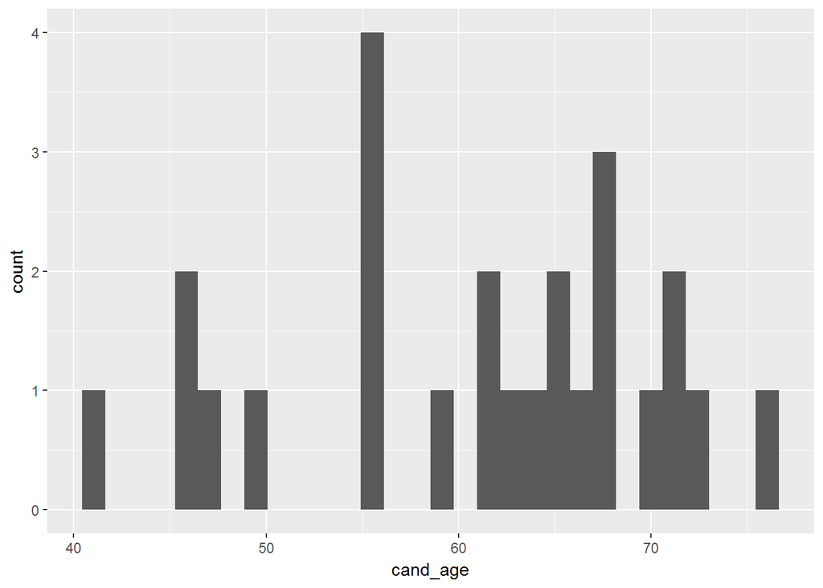

I am curious to see a preliminary view on simple histogram of contribution amount, to know how much usually does each person contributed, and 50% (median) is under $27 dollar, 75% is under $88 dollar, so it is already rare to see individual contribution larger than $200.

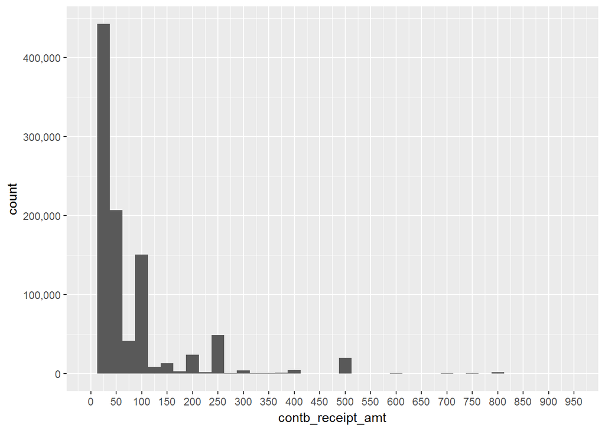

With the hisogram above, I would like to see in table format to see exact number of distribution, but I would group my summary based on range of the contribution amount for clean summary, to summarize to different range => below 0, 0 to 200, 200 to 500, 500 to 1000, 1000 to 2000, 2000 to maximum.

```
## # A tibble: 6 x 5
##          amt_range       n Total_Dollar percent_to_Total percent_occurence
##             <fctr>   <int>        <dbl>            <chr>             <chr>
## 1    (-1.05e+04,0]   16366     -7009465            -4.6%              1.3%
## 2          (0,200] 1159988     49090561            32.4%             88.9%
## 3        (200,500]   84797     27451620            18.1%              6.5%
## 4      (500,1e+03]   17652     16564587            10.9%              1.4%
## 5    (1e+03,2e+03]    4705      7966447             5.3%              0.4%
## 6 (2e+03,1.08e+04]   20838     57540067              38%              1.6%
```

Above table shows the most common contribution is within 0 to 200 dollars, about 88.9% contribution falls in that range. It is also interesting to see there are 16366 negative contribution. Upon further searching online, I believe some are refund back to the contributor upon their request, and some are related to the change of contributor names, but it only occur 1.3% of the time. So I decide to remove the contribution amount less than 0 for simplicity.

Now I am interested to see how each political party receive in terms of number of contribution.

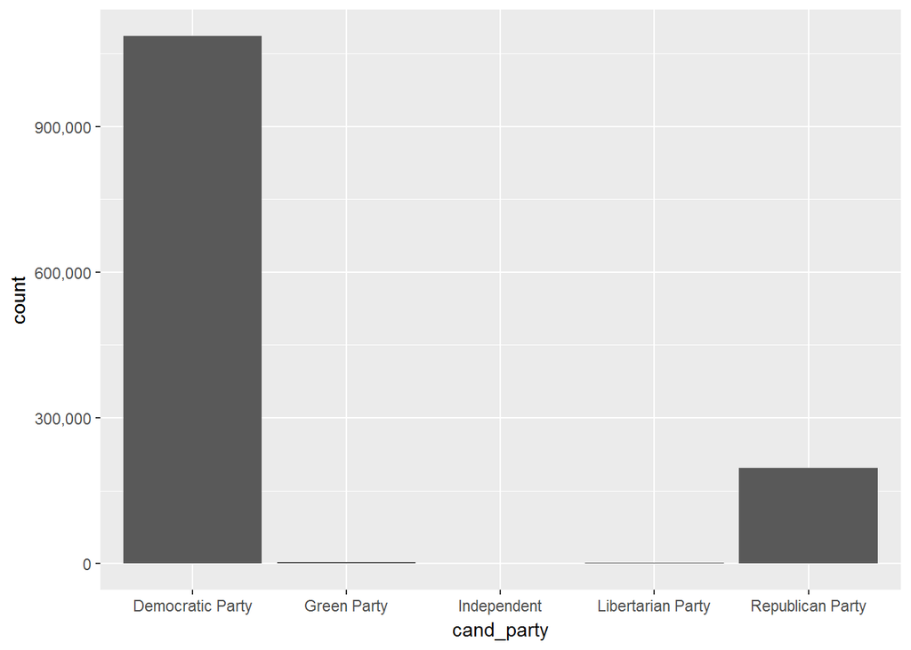

Above histogram shows most of the contribution, over 900,000 contribution to made to democratic party. California is indeed a Democratic state.

Following I would like to see sort the plot from highest count to lowest count for quicker interpretation of the histogram.

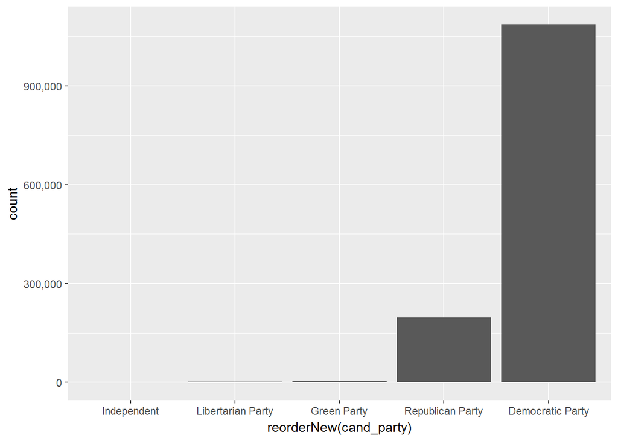

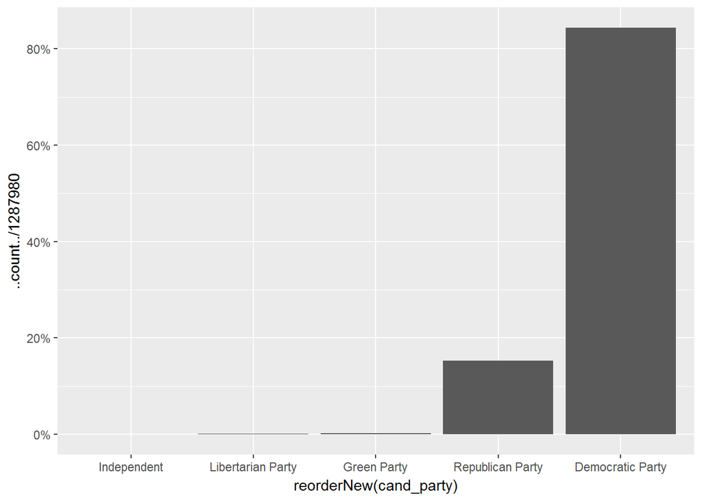

Above plot is ranked by highest to lowest count, and first place is Democratic (receive more than 80% of overall contribution), and second place is Republican Party, while Democratic won by large margin.

Now I am curious to see how many contribution that female candidate get versus male candidate get.

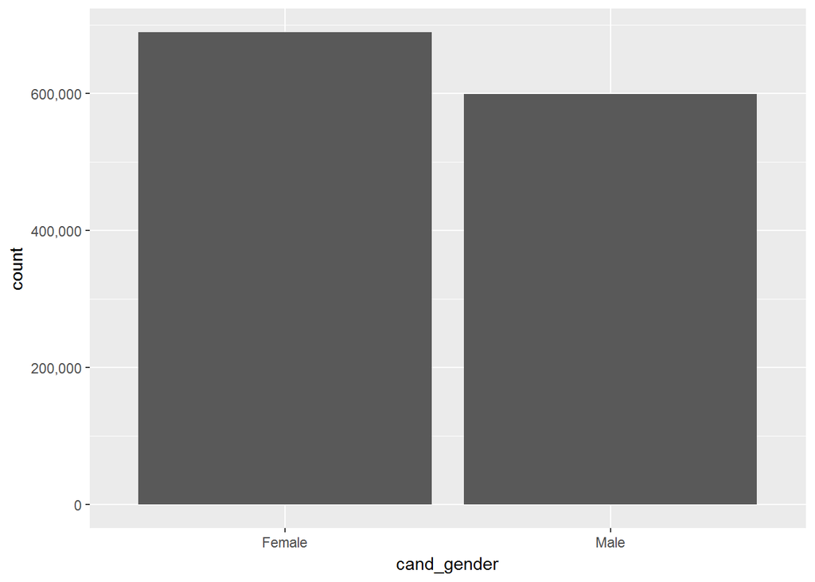

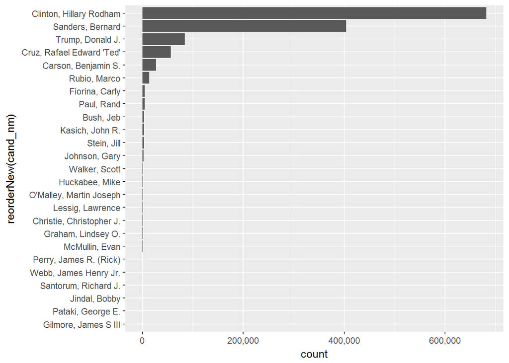

Above histogram verify my understanding that Hillary Cinton is the number 1 candidate that receive the most count of contributio in California, followed by second place Bernard Sanders, and third place Donald Trump.

However, the above plot looks too crowded since it include all 25 candidates, so I’d like to limit my graph to only top 10 candidate.

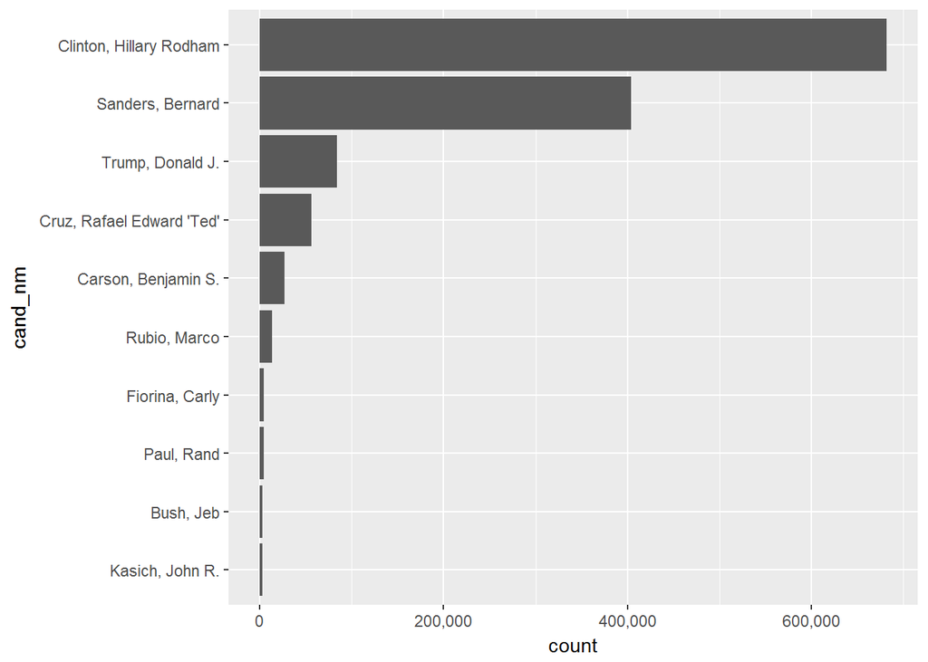

Or, an alternative view that have candidate name on x axis but tilted the text slightly to avoid overlapping.

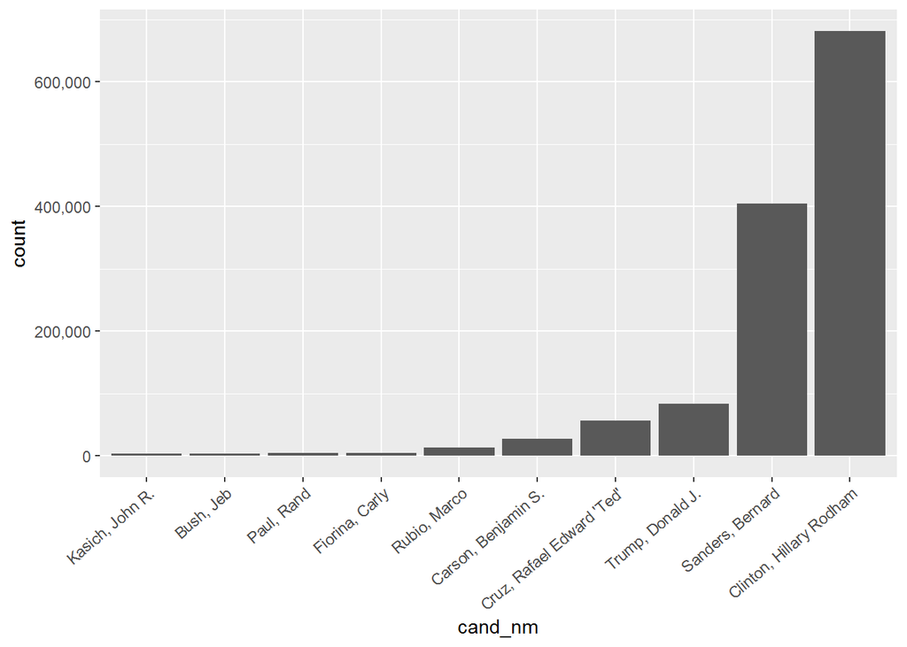

Next, I am interested to see how is the number of contribution fluctuate with time (date). Is there any increasing or decreasing trend, or is there any spike ?

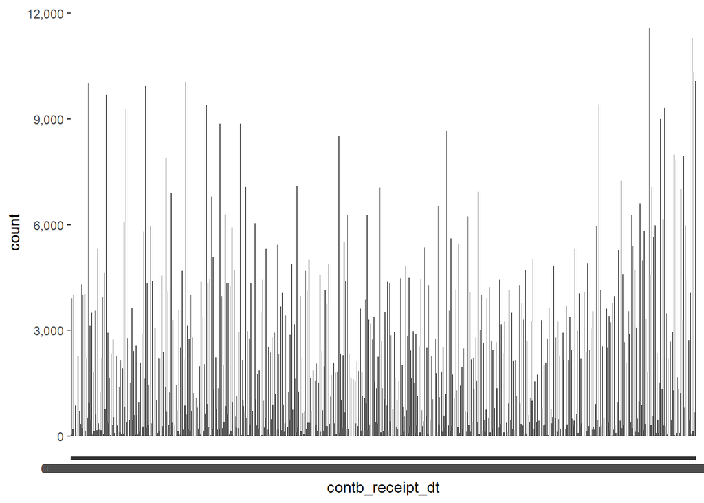

My initial try with simple geom_histogram doesn’t look successful which shows too many flutuation and not even show clear date. I need to find a way to bin it and to show clear period.

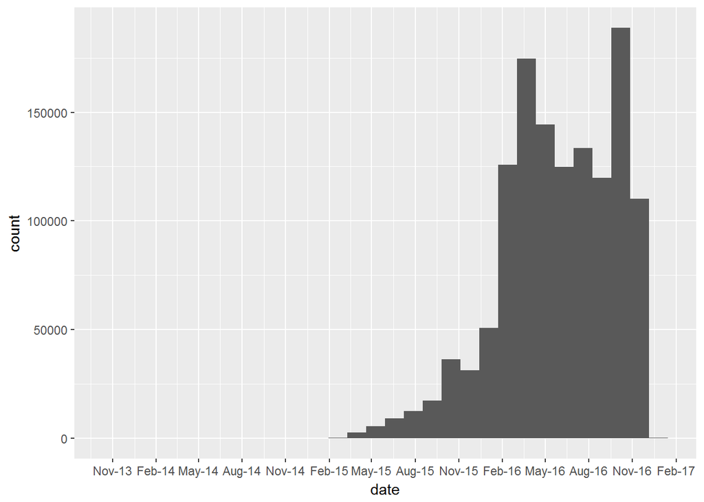

The aboe is better, but I would like to show by each monthly period, and exclude the period that don’t have much activity. So I will tweak further in plot following.

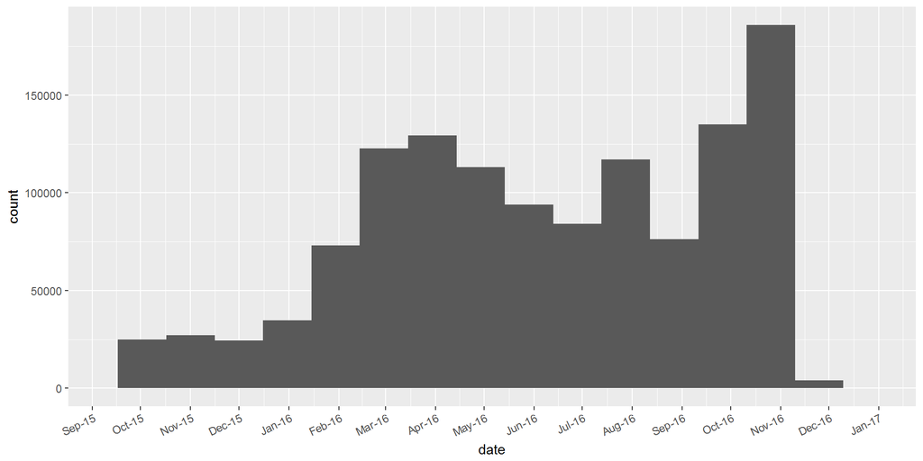

Above I limit the period that exclude bottom 3% and top 3% date from every contribution, and limit to 1 month per histogram. I shows increasing trend that it spike on Nov-16, the month that election day took place. Electrion day is 11/8/2016. Interestingly, between Mar-16 to May-16, there shows spike of number of contribution as well. Perhaps it is due to some presidential campaign effort took place at that time. If I have more data about the campaign activity, I may dig further to see what cause the spike.

```
##         Min.      1st Qu.       Median         Mean      3rd Qu.
## "2013-11-05" "2016-03-10" "2016-05-31" "2016-05-26" "2016-09-12"
##         Max.
## "2016-12-31"
```

```
##           3%          97%
## "2015-09-10" "2016-11-05"
```

Starting 11/5/2013 the first contribution start I can achieve the similar period in plot by hard-code the date as.Date(c(‘2015-09-01’,‘2016-12-31’)) into the ggplot limits, not using percentile.

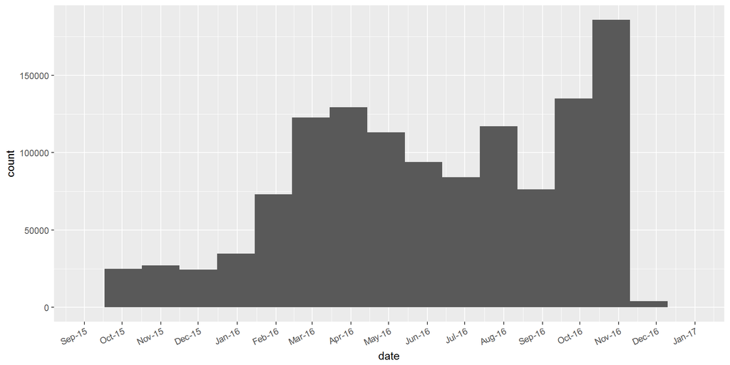

Now I want to explore the number of contribution by county. Below plot is my initial try to visualize it. However, there are clearly too many county to be included, so I need to limit my exploration to top 10 county.

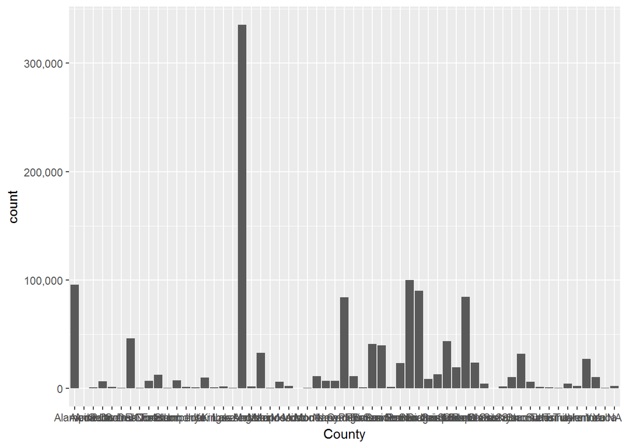

The above histogram is too crowded, so I will limit my histogram to show the top 10 county per below.

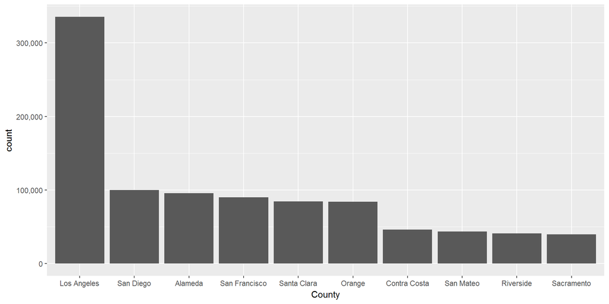

Above plot shows that Los Angeles is the top 1 county that have most number of contribution, and interestingly it exceeds by large margin than the second place San Diego, about 3 times as more contribution. I would like to demonstrate it in terms of % to the total number of contribution 1287980, using plot below. Los Angeles county occupied almost 30% of overall number of contribution.

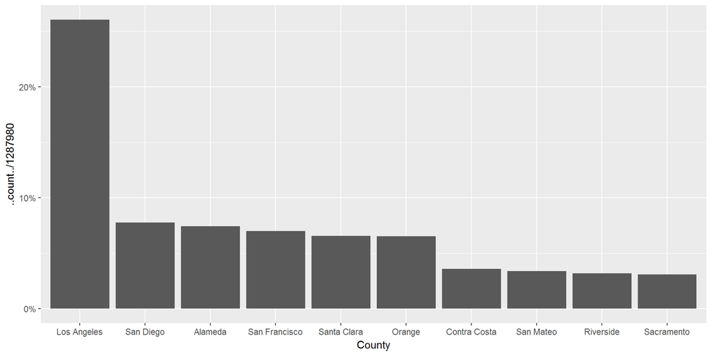

Now I am interested to see the histogram of number of contribution by candidates’ political party. It shows Democratic party got the most, significantly higher than others.

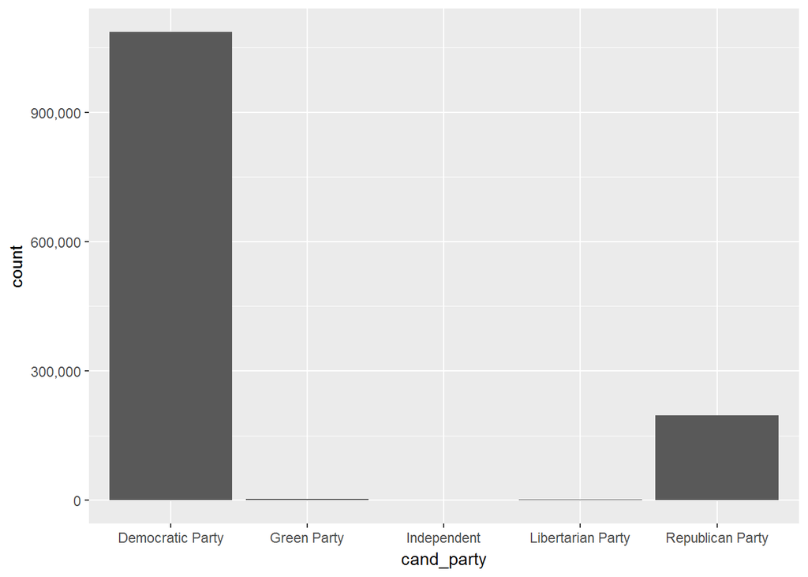

Below plot is converting to percentage, more than 80% are to Democratic party. California is indeed a Demoratic state.

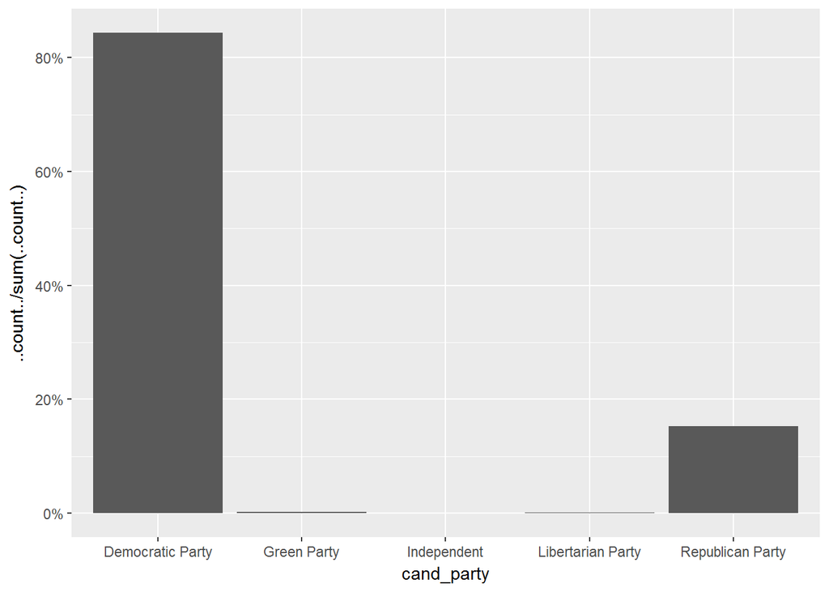

Now I’d like to explore what employers have highest number of contribution. I will limit my exploration to top 30 employers.

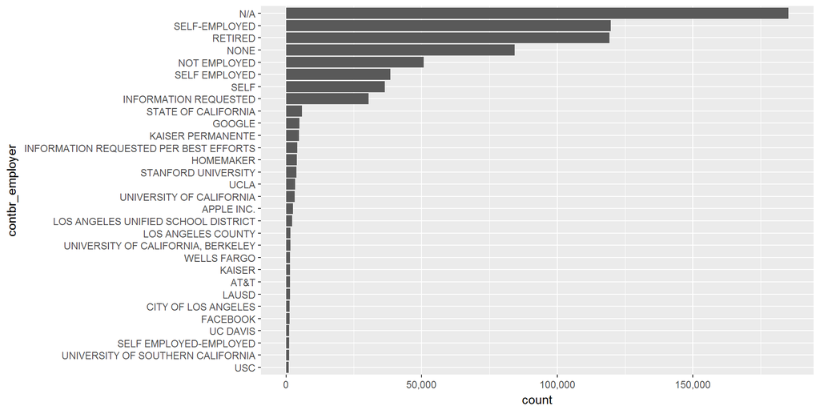

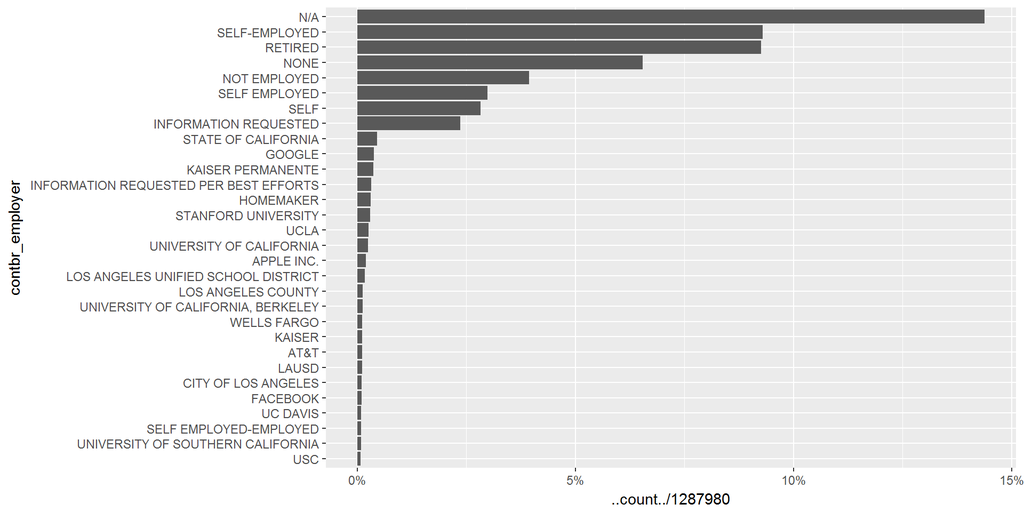

The first company with names show on the list is GOOGLE, followed by KAISER PERMANENTE, and Stanford University, and UCLA, and Apple. These include big tech company, health care provider and University system. It is good to see that school system are also quite involved with the election.

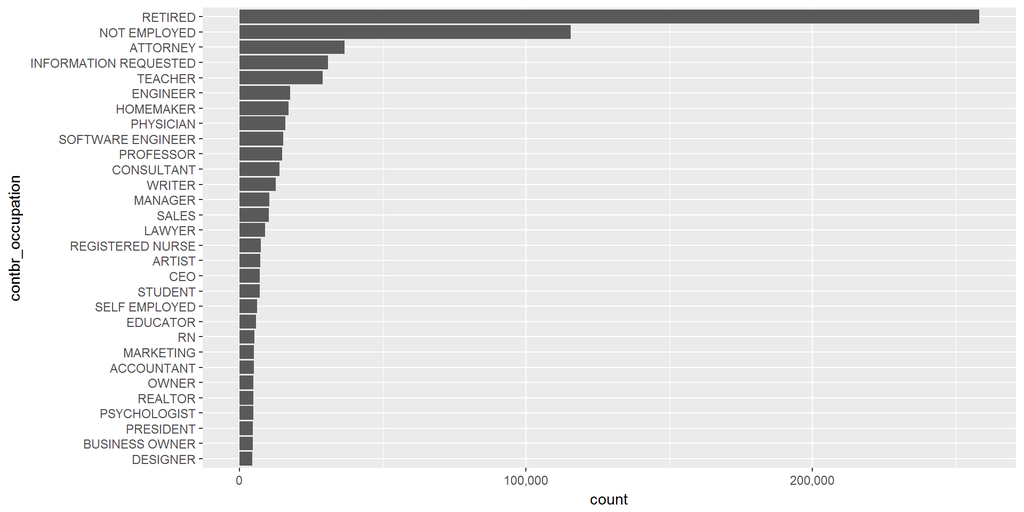

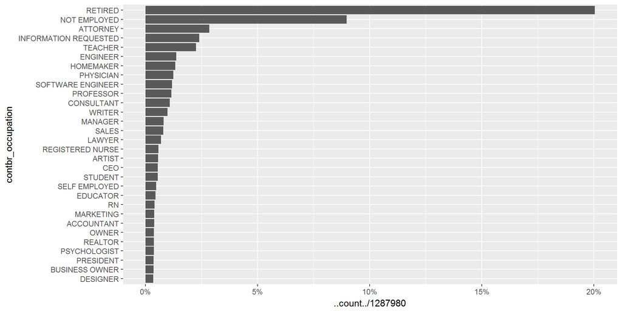

Above plots about occupation to number of contribution, showing again that RETIRED are the largest group of number of contribution at 20% out of overall number of contribution. Not employed is second largest, this could be retired, business owner, not willing to disclose, or simply not working. Attorney is thrid on list, followed by Teacher, Engineer etc. This somehow coincide with the histogram by Employer which shows self-employee, school and high tech company as top contributor’s employer. I feel these are the group that are more involved with election, and are wealthy enough for contribution.

Next, I am curious to see how is the number of contribution by candidates’ age.

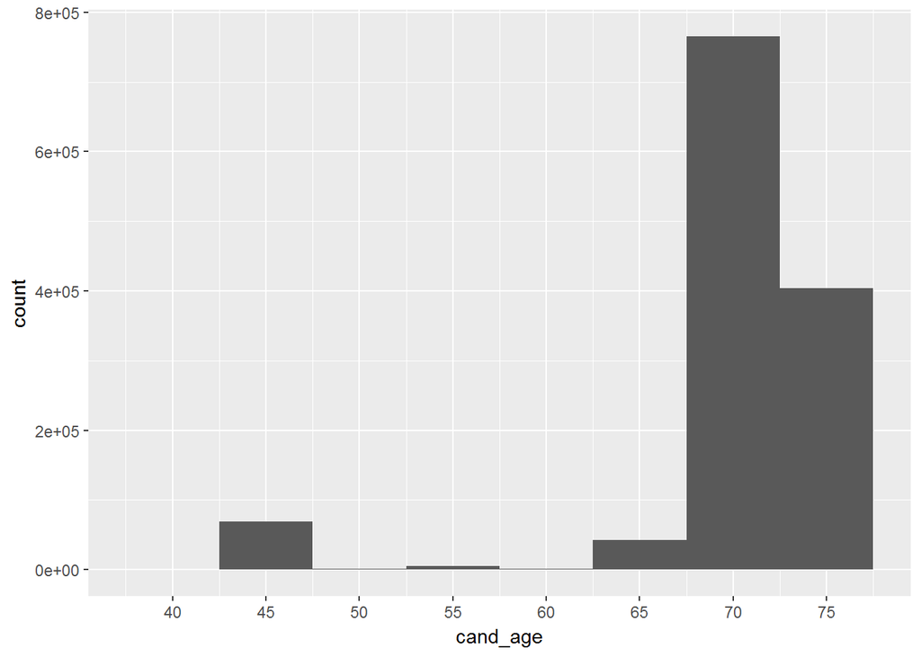

The histogram above shows the candidate at their 70 to 80 year-of-old get the majority of the contribution. Not surprisingly, in earlier plot the top 3 candidates that receive most number contribution are Clinton, Bernard and Trump are all in these age range. I feel this is the age that accumulate most of the experience and connetion needed to run for President.

Next, I would like to see whether Home Residence of the candidates receive the number of contribution.

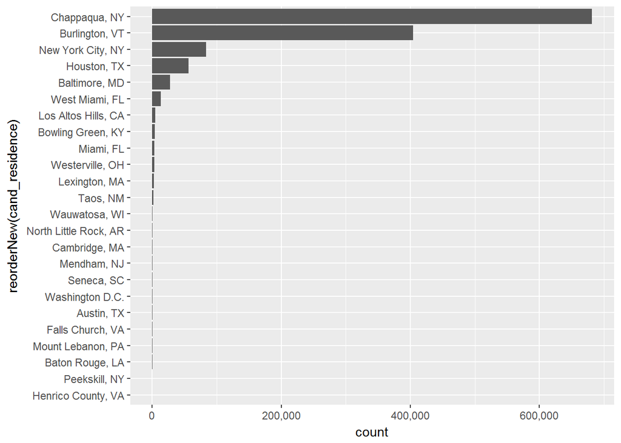

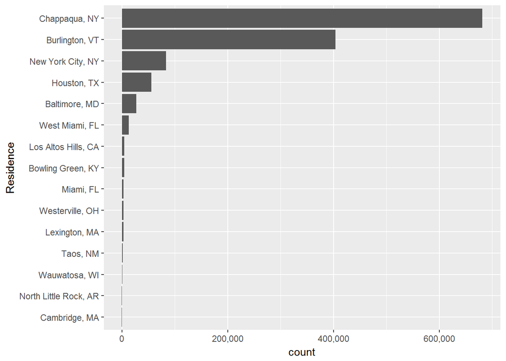

Not surprisingly, the above plot shows top 3 which are for Clinton, Bernard and Donald’s residence. This plot is not particularly meaningfu, but good to know 2 of the top candidates residence in New York.

# Univariate Analysis

### What is/are the main feature(s) of interest in your dataset?

The main feature of interest is Contribution amount (contb_receipt_amt). I want to see how other variable related to the contribution amount.

### What other features in the dataset do you think will help support your investigation into your feature(s) of interest?

City, county, candidate’s political party and Dates may show some trend to the distribution of contribution amount.

### Did you create any new variables from existing variables in the dataset?

Yes, I created County variable which is a way to group multiple zip code into larger group for easier visualization and also will be used to create the map plot in 2D analysis. Also, I created variables related to candidate’s info such as gender, political party and age. Lastly, I reconstruct the Date column to allow ggplot to interpret it and visualize the trend.

### Of the features you investigated, were there any unusual distributions? Did you perform any operations on the data to tidy, adjust, or change the form of the data? If so, why did you do this?

The highest number of contribution are in Los Angeles which is almost 30% of total number of contribution. Comparing to the number 2 is San Diego which is less than 10%, so Los Angeles exceed by large margin which is kind of interesting. However, I will do similar comparison by contribution amount in 2D analysis, rather than purely by the number of occurence, which may reveal different picture.

I convert the contribution date column (contb_receipt_dt) from string date format dd-MMM-yy into actual date format using to.Date function, so that I can plot on the date in histogram format. I also trim the zip code into 5 digit format so that I can do join table by zip code to generate “County” column more accurately.

# Bivariate Plots Section

I am curious whether I can find any correlation between the continuous variables, which in my dataset include contribution amount, candidate’s age and date. Shows below, but it doesn’t show significant correlation. I interpret it as that each contributor’s contribution amount doesn’t show higher or lower based on the candidate’s age, and doesn’t change much as it closer to electrion day. To clarify, I see clear trend from above plot saying the closer to electrion the more “total” contribution amt it is, and the top candidate are all have higher age. But the correlation here is “per person contribution amount”, this per contribution amount is rather flat. I will use scatter plot to verify this later on.

```
##                   contb_receipt_amt    cand_age        date
## contb_receipt_amt         1.0000000 -0.11225357 -0.13497405
## cand_age                 -0.1122536  1.00000000  0.09352419
## date                     -0.1349740  0.09352419  1.00000000
```

Now I’d like to explore the contribution amt distribution between different parties. Boxplot is good for this purpose. The Democratic party has the most narrow inter-quartile range, while Green and Libertarian has highest inter-quartile range. I interpret it as follows: although Democratic party get most of the contribution, but on average contribution amount is lower than the other party that have less number of contribution. I think the less popular party may have more highly-devoted contributor that are willing to contribute high amount.

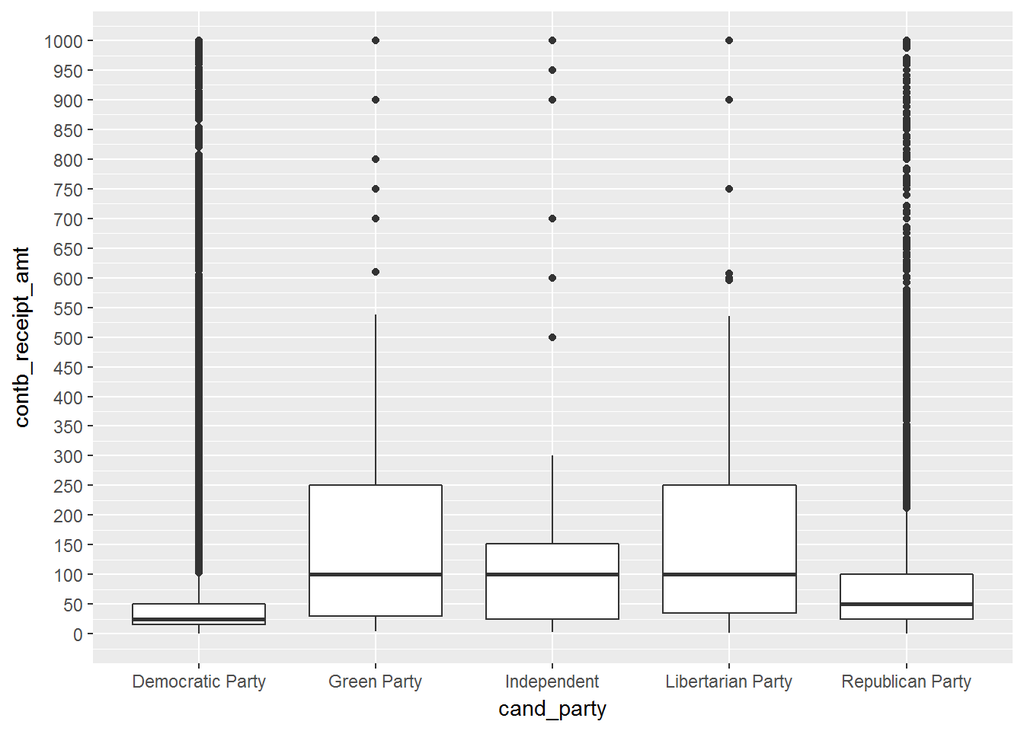

Next, I would like to see the contribution amount distribution by candidate. Using boxplot below, and rank from the candidate getting highest total contribution amount to the lowest.

```
##  [1] Clinton, Hillary Rodham   Sanders, Bernard
##  [3] Trump, Donald J.          Cruz, Rafael Edward 'Ted'
##  [5] Rubio, Marco              Bush, Jeb
##  [7] Carson, Benjamin S.       Kasich, John R.
##  [9] Fiorina, Carly            Paul, Rand
## 25 Levels: Bush, Jeb Carson, Benjamin S. ... Webb, James Henry Jr.
```

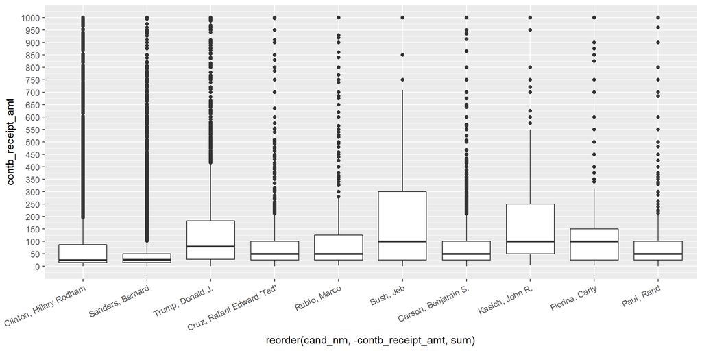

The above boxplot shows that Hillary’s per contributor’s contribution amount inter-quartile range is second to the lowest, just higher than Bernard. Although these 2 candidates have top 2 highest total contribution amount, but in terms of per contributor’s contribution amount they are the lowest. My interpretation is these two are getting lots more population of contribution which represent a more average contribution amount, in contrast to other candidates which attract more special-interest group’s contribution, who are willing and capable of making higher contribution amount.

Next, I will see the total contribution amount by candidates. The top 4 orders are aligned with the rank of number of contributor, but starting the 5th place this shows Marco Rubio, while the number of contributor plot is Benjamin Carson.

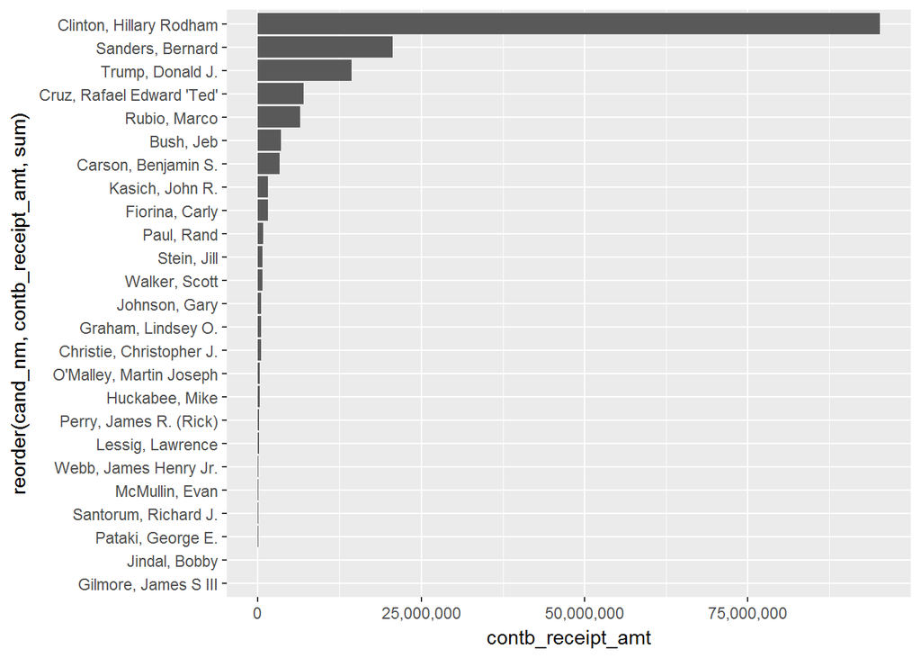

Next, I’d like to visualize the contribution count and total amount by actual geographical map. I think this kind of visualization may give me more concrete idea about the distribution by location.

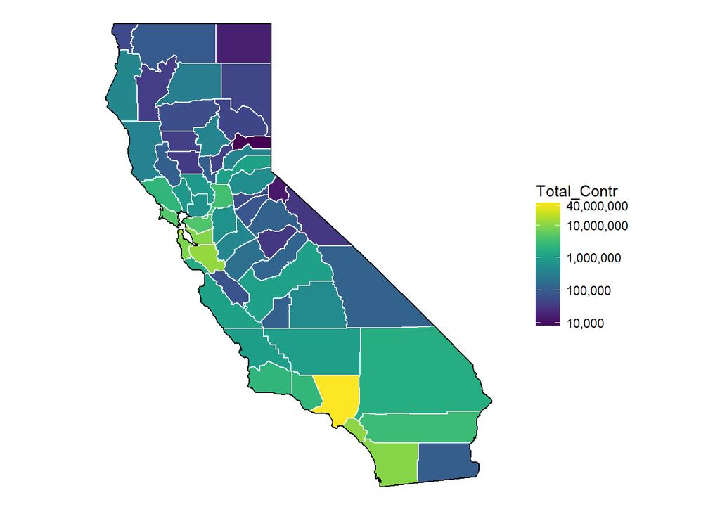

The plot above shows an area at bottom left that has highest contribution amount more than $40 million (yellow area). In the dataframe summary followed immediately follow shows it is Los Angeles area. And the second brightest color is in the West slightly above the middle, which is the San Francisco County, and then Santa Clara county that adjacent to it. From my observation to the county area size, the Los Angeles county is larger than San Francisco and Santa Clara county combined, that may explain why the total contribution amount in Los Angeles are much higher than San Francisco or Santa Clara alone. If I combine San Francisco and Santa Clara together, the difference gap with Los Angeles are much smaller. These 3 areas are also the richest and population-densed with working professional and companies, so it makes sense to see these are the top 3 areas with highest total contribution amount.

```
## # A tibble: 10 x 4
##           County Total_Contr      n contr_per_person
##            <chr>       <dbl>  <int>            <dbl>
##  1   Los Angeles    49353868 335482        147.11331
##  2 San Francisco    15857027  89951        176.28517
##  3   Santa Clara    12338977  84486        146.04760
##  4        Orange    11251632  84152        133.70605
##  5     San Diego    10226246 100057        102.20420
##  6       Alameda    10066835  95783        105.10043
##  7     San Mateo     9112487  43428        209.82976
##  8         Marin     4695365  32619        143.94571
##  9  Contra Costa     4449355  46241         96.22099
## 10    Sacramento     3624246  39873         90.89474
```

Next, I’d like to see the distribution of average contribution per contributor on the map.

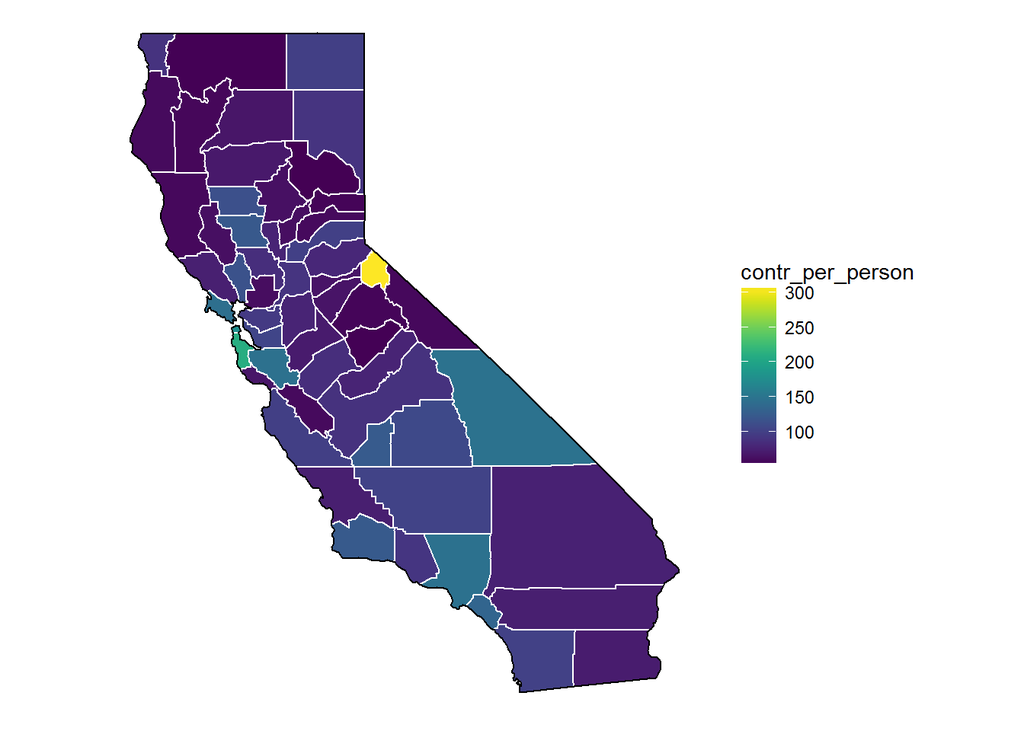